# Walkthrough – Integrative analysis of cells from control and Hedgehog (Hh) activation conditions during skin wound healing

Lihua Zhang

We showcase scMC’s capability of detecting context-shared and -specific biological signals by applying it to two mouse skin scRNA-seq datasets containing cells from control and Hedgehog (Hh) activation conditions during skin wound healing.

## Load the required libraries

```r
library(scMC)
library(cowplot)
```

## Load data

scMC takes a list of multiple digital data matrices as input. Features should be in rows and cells in columns. Rownames and colnames should be included.

The scRNA datasets we demonstrated here, including two count data matrices for the control and Hh activation conditions, can be downloaded via this shared Google Drive [link](https://drive.google.com/file/d/182EMDA0x5fr2nV7MbC4SDISSjFBS1E0p/view?usp=sharing).

```r
load("/Users/suoqinjin/Downloads/scMC/tutorial/data_dermis.rda")
data_list = data_dermis # a list of count data matrix, one per dataset
```

## Create a scMC object

```r
scMC <- create_scMC(raw.data = data_list)
```

## Preprocess data

```r
scMC <- preprocessing(scMC, add.names = c("Control","Hh activation"), cell.prefix = TRUE)
```

## Identify cell clusters for each dataset

```r
scMC <- identifyNeighbors(scMC, mode = "separate")
scMC <- identifyClusters(scMC, mode = "separate")
```

```
#> Identifying cell clusters in Dataset  1
#> The initial guessed number of clusters is  9
#> Identifying cell clusters in Dataset  2
#> The initial guessed number of clusters is  8
```

## Detect confident cells in each cell cluster

```r
scMC <- identifyConfidentCells(scMC)
```

## Identify marker genes associated with the putative cell clusters in each dataset

```r
scMC <- identifyMarkers(scMC, mode = "separate")
```

## Learn technical variation between any two datasets

```r
structured_mat <- learnTechnicalVariation(scMC)
```

## Learn a shared embedding of cells across all datasets after removing technical variation

```r
scMC <- integrateData(scMC, structured_mat)
```

## Perform an integrated analysis

Run the standard workflow for clustering

```r
scMC <- identifyNeighbors(scMC, mode = "integrated")
scMC <- identifyClusters(scMC, mode = "integrated", resolution = 0.04)
```

```
#> Identifying cell clusters in the integrated space
#> The number of clusters in the integrated data is  6
```

```r
scMC <- runUMAP(scMC, reducedDims = "integrated")
```

## Visualize cells onto the low-dimensional space

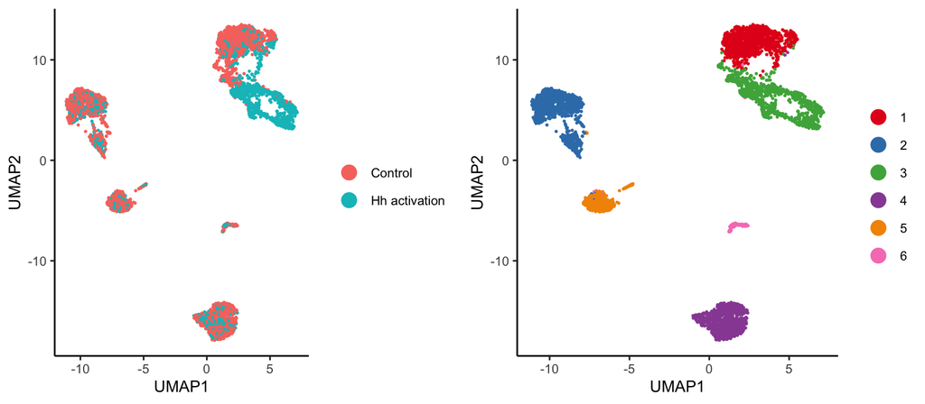

```r
gg1 <- cellVisualization(scMC, color.by = "sample.id", colors.ggplot = T)
gg2 <- cellVisualization(scMC, color.by = "Integrated clusters")
cowplot::plot_grid(gg1, gg2)
```

## Overlay the expression of features onto the low-dimensional space

We can overlay the expression of features onto the low-dimensional space. Here we overlay the expression levels of fibroblasts pan-markers (Pdgfra and Lox) and Hh-active fibroblast markers (Ptch1 and Gil1) onto the UMAP space.

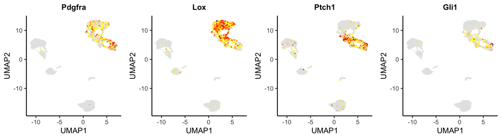

```r
featureVisualization(scMC, feature.use = c('Pdgfra','Lox','Ptch1','Gli1'),  nCol = 4, cell.size = 0.1, show.legend = F, show.legend.combined = F)
```